# DATA 550 Lab 3 - Communication visualizations

There are two versions of this lab, one in Python and one in R. The R lab will use `ggplot` and the Python lab will use `Altair`.

This is the R version.

Each partner should choose a version to complete, though keep in mind that **you are required to alternate between completing the R labs and the Python labs** to get experience using both languages.

## Acknowledgemnts

This lab was lightly adapted from the one created by Joel Ostblom for the DSCI 531 version of Data Viz I in the 2020/21 Academic year.

## Submission instructions

rubric={mechanics:2}

You receive marks for submitting your lab correctly, please follow these instructions:

- Create a GitHub Repo for your group.
  - Keep this organized, i.e. with a separate clearly marked folder for each assignment.
- [Click here to view a description of the rubrics used to grade the questions](https://github.com/UBC-MDS/public/tree/master/rubric)
- Push your `.ipynb` file to your GitHub repository for this lab.
- Include a clickable link to your GitHub repo for the lab just below this cell
  - It should look something like this https://github.ubc.ca/folder_path/DATA_550_labX_groupY.
- Upload a `.html` version of your assignment to Canvas.
  - Run all cells in your notebook to make sure there are no errors by doing `Kernel -> Restart Kernel and Run All Cells...`
  - Convert your notebook to .html format using `File -> Save and Export Notebook As -> HTML`
  - Submit and double check that your have submitted the correct file to Canvas

## 0. So we meet again...

I am sure you have heard, turns out Bestflix did not make it. Copyright issues they said, can you believe it?? I can't, there must have been more to this story... And the only other person with knowledge of this enterprise was... YOU!

In the spirit of a true comic book criminal, I will scale my revenge for this set back completely out of proportion and attempt world dominion. Don't worry, there will be no blood shed, I operate with class so my plan here is to brainwash people into thinking that I am actually good for them and then reap personal benefits once in power, creative isn't it?

To convince the pleb... I mean honorary citizens of the world to vote for me, I have made several key visualizations showing what an ideal candidate I am. The only way to stop me (hmm why am I telling you this again...) is to debunk these visualizations and show voters the errors of my ways (this is clearly a fictional scenario since we are assuming that each person acts rationally and is convinced by data).

Below is my publicly distributed campaign material covering these four main area:

1. The current dramatic increase in job dissatisfaction
2. My previous record on increasing job wages for all
3. Guns to the people
4. My great approval rating

For each figure that I have made, I have also included the underlying data (imagine what a wonderful world it would be if that actually happened in real life...). You can find these datasets in your lab repo). For each question in this lab, your team has the following three tasks:

1. Decide if you think my plot and my claim is misleading or not, why you think so, and how you would improve it in your version of the same figure (unless you think mine is already good). In addition to what we are learning this week, you will need to draw on your knowledge from last week for when certain plots are suitable and which are common pitfalls to avoid.
2. To earn the people's trust, you need to recreate my plot to show that you know what I did. This includes axis labels, legends, colors, titles, figure size, everything as close as possible to the images I have pasted for each question below.
3. Create your own better version of the same figure. Make sure that your choices are motivated in writing in point 1.

# 1. Dramatic decline in job satisfaction

## The data

The `cities-job-satisfaction.csv` dataset contains (fictional) data from different cities around the world. In this data it was measured which proportion of people reported that they were unsatisfied with their work situation this year compared to last year. Each data point is a different city, and the value indicates the proportion of dissatisfied workers.

## My plot

### ggplot

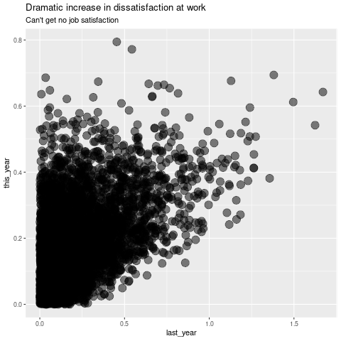

## My claim

You can clearly see in this plot that people are dramatically more dissatisfied at work this year compared to last year. I have used transparency for the dots to prevent overplotting/oversaturation, so this means that the entire dark area has an even amount of cities throughout. In other words, there are as many cities that increased from ~0% to ~40% dissatisfaction as there are cities that stayed around 0%. That's atrocious!

### Question 1.1

rubric={reasoning:2,writing:1}

- Explain which mistakes (if any) I have done in my plot and provide an interpretation of the data that is more correct than mine. Be brief and clear in your answer.
- You might have some ideas just from looking at my plot, but you will likely need to do some investigation yourself to answer this question fully. You can reference your improved plot as needed.

One major issue with my original interpretation is that I treated darker regions in the plot as representing an even distribution of cities across the entire area. However, the darkness is caused by overlapping points due to transparency and does not mean that all values in that region are equally frequent.

Each point represents one city, so the plot should be interpreted by comparing individual locations rather than the shaded area. In particular, cities above the diagonal line would indicate higher dissatisfaction this year, while cities below indicate a decrease.

The plot shows that many cities remain clustered at relatively low dissatisfaction levels in both years, near the lower-left region. Although some cities experienced substantial increases (reaching 30–40% or higher), these are not representative of all cities.

Therefore, the data does not support the conclusion that dissatisfaction has dramatically increased everywhere. A more accurate interpretation would require summary statistics, such as the proportion of cities with increased dissatisfaction or changes in the median level.

### Question 1.2

rubric={accuracy:2}

#### R

Recreate my ggplot version of the plot. Your plot should look as close as possible to mine in the image above.

1. 'cities-job-satisfaction.csv'

2. 'guns-r-us.csv'

3. 'lab3-Python.ipynb'

4. 'lab3-R.ipynb'

5. 'lab3.ipynb'

6. 'state-comparison.csv'

7. 'wages.csv'

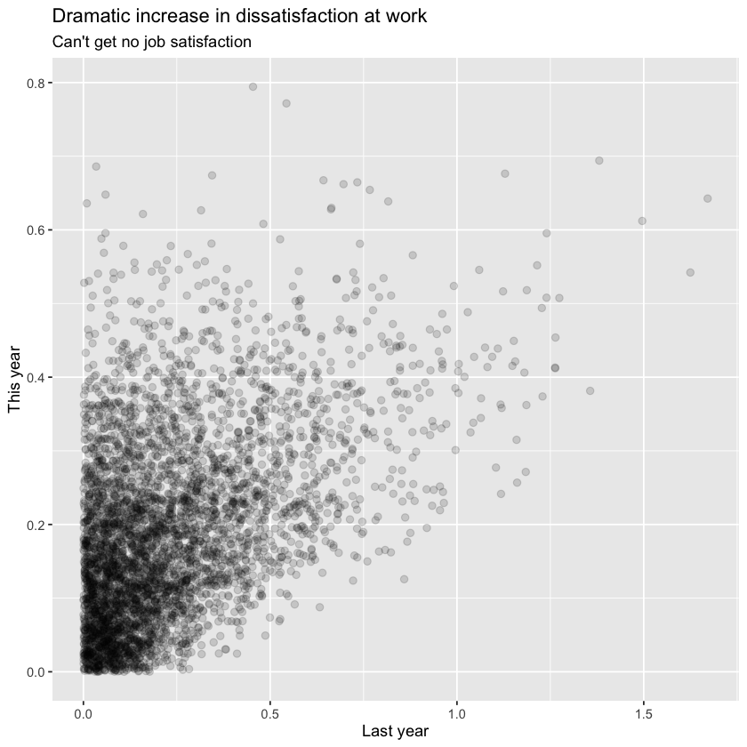

```r
library(ggplot2)

list.files()

df <- read.csv("cities-job-satisfaction.csv")

ggplot(df, aes(x = last_year, y = this_year)) +
  geom_point(color = "black", alpha = 0.15, size = 2) +
  labs(
    title = "Dramatic increase in dissatisfaction at work",
    subtitle = "Can't get no job satisfaction",
    x = "Last year",
    y = "This year"
  ) +
  theme_grey()
```

### Question 1.3

rubric={viz:2}

#### R

Improve my ggplot plot. Chose the best type of plot to accurately reveal what the data looks like. Design the plot to be an effective plot for communication purposes, this includes proper figure size, axis/figure titles, font sizes, colors, etc.

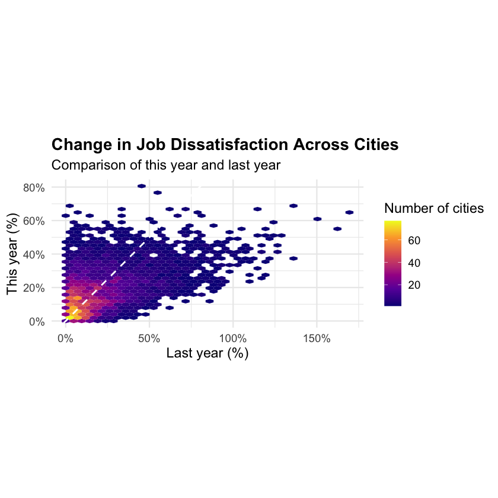

```r
library(ggplot2)
library(scales)

ggplot(df, aes(x = last_year, y = this_year)) +


  geom_hex(bins = 35) +


  geom_abline(
    slope = 1,
    intercept = 0,
    linetype = "dashed",
    color = "white",
    linewidth = 0.8
  ) +


  scale_fill_viridis_c(
    name = "Number of cities",
    option = "C"
  ) +


  scale_x_continuous(labels = percent_format(accuracy = 1)) +
  scale_y_continuous(labels = percent_format(accuracy = 1)) +


  labs(
    title = "Change in Job Dissatisfaction Across Cities",
    subtitle = "Comparison of this year and last year",
    x = "Last year (%)",
    y = "This year (%)"
  ) +


  coord_equal() +


  theme_minimal(base_size = 14) +
  theme(
    plot.title = element_text(face = "bold"),
    legend.position = "right"
  )
```